# Lalonde 3 Ways

Environemnt setup and data Prep

```r
library(randomForest)
```

# 1. MULTIVARIATE REGRESSION

Creating a Multivariate regression of real earnings

```r
#multivariate regression of real earnings
lm2 <- lm(re78 ~ treat + educ + re75 + age + black + hisp + nodegr + u74 + u75 + married, data=lalonde)
summary(lm2)
```

```
Call:
lm(formula = re78 ~ treat + educ + re75 + age + black + hisp +
    nodegr + u74 + u75 + married, data = lalonde)

Residuals:
   Min     1Q Median     3Q    Max
 -9113  -4456  -1609   3048  53306

Coefficients:
              Estimate Std. Error t value Pr(>|t|)
(Intercept)  1285.0634  3448.6176   0.373   0.7096
treat        1605.5218   640.1676   2.508   0.0125 *
educ          371.7119   228.1403   1.629   0.1040
re75            0.1202     0.1323   0.908   0.3643
age            53.4331    45.8575   1.165   0.2446
black       -2049.8534  1174.9980  -1.745   0.0818 .
hisp          230.1306  1560.0865   0.148   0.8828
nodegr       -200.5898   998.3066  -0.201   0.8408
u74           622.3750  1059.5222   0.587   0.5572
u75          -841.9766  1012.9377  -0.831   0.4063
married      -155.1317   883.2236  -0.176   0.8607
---
Signif. codes:  0 '***' 0.001 '**' 0.01 '*' 0.05 '.' 0.1 ' ' 1

Residual standard error: 6524 on 434 degrees of freedom
Multiple R-squared:  0.05393,   Adjusted R-squared:  0.03213
F-statistic: 2.474 on 10 and 434 DF,  p-value: 0.00689
```

```r
coefficients(lm2)
```

```
  (Intercept)         treat          educ          re75           age         black          hisp        nodegr
 1285.0634269  1605.5218160   371.7118909     0.1201764    53.4330546 -2049.8533659   230.1306281  -200.5897827
          u74           u75       married
  622.3749736  -841.9766166  -155.1317325
```

CONFIDENCE INTERVALS for the variables of the multiple regression

```r
confint(lm2,parm="treat",level = 0.95)
```

```
         2.5 %   97.5 %
treat 347.3076 2863.736
```

## (1.d) Are estimated treatment effects higher for individuals with (or without) a high school degree?

Let’s check. I will split the dataset by degree and nondegree

```r
dim(data_nodegree)
```

```
[1] 348  12
```

fitting regressions for degree and no degree

```r
lm_nodgr <- lm(re78 ~ treat + educ + re75 + age + black + hisp + nodegr + u74 + u75 + married, data = data_nodegree)
lm_dgr <- lm(re78 ~ treat + educ + re75 + age + black + hisp + nodegr + u74 + u75 + married, data = data_degree)

#view regression results
summary(lm_nodgr)
summary(lm_dgr)
#view specifically the coefficients
coefficients(lm_nodgr)
coefficients(lm_dgr)
#view confidence intervals of coefficients
confint(lm_nodgr)
confint(lm_dgr)
```

[output not shown]

# 2. RANDOM FOREST REGRESSION

### 2.a - fit random forest model, fitting 78 onto the same predictors as before

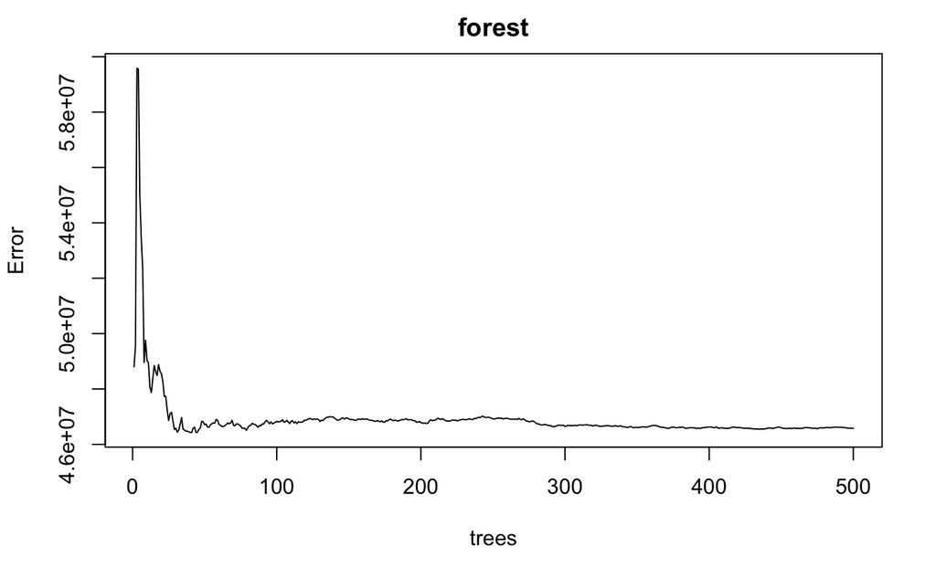

#### 2.a - predictor importance table

We see by the variable importance table and plot how “important” was each variable. Meaning, if we took out this variable, by how much percent would are Mean Squared Error increase? We see that unemployment in 74 ,black, unemployment in 75 and real earnings 75 were more instrumental for our Forest’s accuracy. interestingly, the treatment variable is only after these and years of education 6th in importance, and has relatively low inc-node purity.

```r
importance(forest)
```

```
           %IncMSE IncNodePurity
treat    1.6056476     705995442
educ     1.8634786    2007379476
re75     4.8240844    3175975960
age     -1.1807237    2882597995
black    6.6403422     510836106
hisp     0.9970894     200453208
nodegr  -1.9366423     359290496
u74      7.7255321     549209200
u75      4.8470814     371740229
married  0.6216298     395739306
```

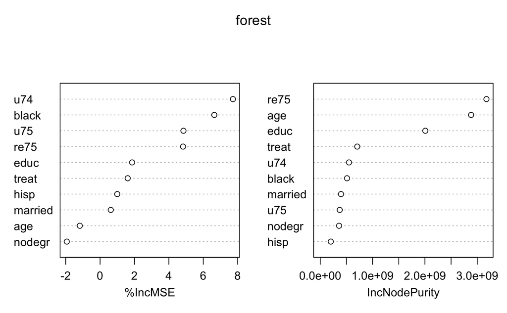

```r
varImpPlot(forest)
```

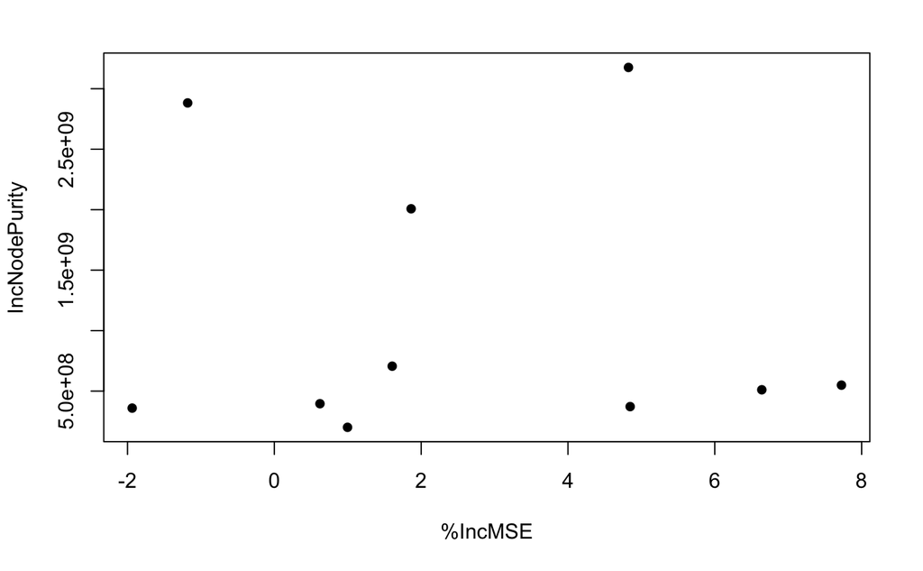

```r
plot( importance(forest), lty=2, pch=16)
```

## 2.b - predict treatment effect for the treatment units

```r
#create dataset of only treated units, without re78
data_treated <- lalonde[treat == 1,]
data_treated_cf <- lalonde[treat == 1,]
#dim(data_treated)
#head(data_treated_cf)
```

2.b - We’ll predict counterfactual estimated for what would be the real earnings for the treated units if they weren’t treated? Then we’ll calculate the treatment effect based on the test statistic of the mean difference between each unit’s potential outcomes, if treated (as in reality) or if it weren’t treated (estimated).

```r
mean(data_treated_cf$re78 - rf_predicted_cf)
```

```
[1] 1273.414
```

We see the treatment effect for the all treated units is $1273.414. Meaning, the treated units are estimated to have gained $1273.414 on average by the program.

## 2.C - Degree / vs NoDegree Random Forest

Now we want to test the same: the difference in potential outcomes for the treated people, but seperately for people who have a degree and for people without a degree.

```r
# create dataset of only treated units, without re78
treated_yesdegree <- subset(data_treated, nodegr == 0)
treated_nodegree <- subset(data_treated, nodegr == 1)

#view and verify our subdatasets look right, if we want:
#head(data_degree)
#head(data_nodegree)
#dim(data_degree)
#dim(data_nodegree)
```

### 2.C - Predict counterfactuals for each subgroup

First, we will create new datasets that will be the same dataset of the treated units, but would “fake” the same units to be in the control group, by changing “treat” from “1” to “0”.

```r
#create new datasets that will contain counterfactuals
treated_yesdg_cf <- subset(treated_yesdegree, nodegr == 0)
treated_nodg_cf <- subset(data_treated, nodegr == 1)
#change all "treated = 1" to 0 (control)
treated_yesdg_cf$treat <- 0
treated_nodg_cf$treat <- 0
```

Now we will predict the earnings in 1978 for each subgroup.

```r
#use predict function, basing on the forest model fitted upon the entire dataset, what would be the results of
predicted_re78_yesdg_treated_cf <- predict(forest,data=treated_yesdg_cf)
predicted_re78_nodg_treated_cf <- predict(forest, data=treated_nodg_cf)
```

### 2.C1 - WITH DEGREE COMPARISON.

Comparing the potential outcomes for the people WITH DEGREE who were treated (in the program). This means we estimate how much would they have gained from wether they haven’t been given the treatment.

```r
#viewing each mean
print("average earnings in 1978 for treated with degree")
```

```
[1] "average earnings in 1978 for treated with degree"
```

```r
mean(treated_yesdegree$re78)
```

```
[1] 8046.521
```

```r
print("predicted mean earnings in 1978 for treated people with degree IF THEY HAVE NOT BEEN IN THE PROGRAM")
```

```
[1] "predicted mean earnings in 1978 for treated people with degree IF THEY HAVE NOT BEEN IN THE PROGRAM"
```

```r
mean(predicted_re78_yesdg_treated_cf)
```

```
[1] 5398.7
```

```r
#treatment effect (only treated)
print("treatment effect for treated people WITH DEGREE")
```

```
[1] "treatment effect for treated people WITH DEGREE"
```

```r
mean(treated_yesdegree$re78) - mean(predicted_re78_yesdg_treated_cf)
```

```
[1] 2647.821
```

```r
#plot WITH DEGREE counterfactual comparison
plot(density(treated_yesdegree$re78), xlim = c(-11000,46000),ylim = c(0,0.00025), col="green", main = "Density of earnings for people WITH a degree", ylab = "Density", xlab = "Earnings 78")
lines(density(predicted_re78_yesdg_treated_cf),col="red")
```

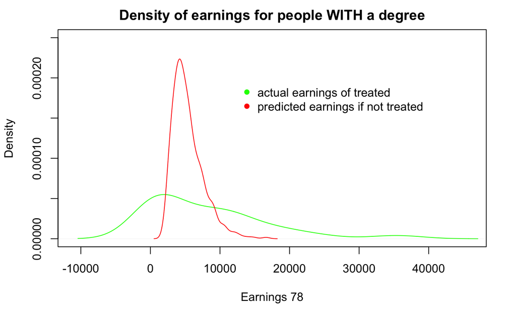

```r
legend(x=40000, y=0.00020, xjust=1, col = c("green","red"), legend = c("actual earnings of treated", "predicted earnings if not treated"),  bty="n", pch= c(16, 16) )
```

So, the treatment effect for treated people WITH DEGREE is: $2647.82

### 2.C2 - WITH NO DEGREE COMPARISON

```r
#treatment effect of treated people without degree
print("average earnings in 1978 for treated with NO degree")
```

```
[1] "average earnings in 1978 for treated with NO degree"
```

```r
mean(treated_nodegree$re78)
```

```
[1] 5649.464
```

```r
print("predicted mean earnings in 1978 for treated people with NO degree IF THEY HADN'T BEEN TREATED")
```

```
[1] "predicted mean earnings in 1978 for treated people with NO degree IF THEY HADN'T BEEN TREATED"
```

```r
mean(predicted_re78_nodg_treated_cf)
```

```
[1] 5398.7
```

```r
print("treatment effect for treated people with NO degree")
```

```
[1] "treatment effect for treated people with NO degree"
```

```r
mean(treated_nodegree$re78) - mean(predicted_re78_nodg_treated_cf)
```

```
[1] 250.7643
```

```r
#plot WITHOUT DEGREE counterfactual comparison
plot(density(treated_nodegree$re78), xlim = c(-11000,46000),ylim = c(0,0.00025), col="blue", main = "Density of earnings for people with NO degree", ylab = "Density", xlab = "Earnings 78")
lines(density(predicted_re78_nodg_treated_cf),col="orange")
```

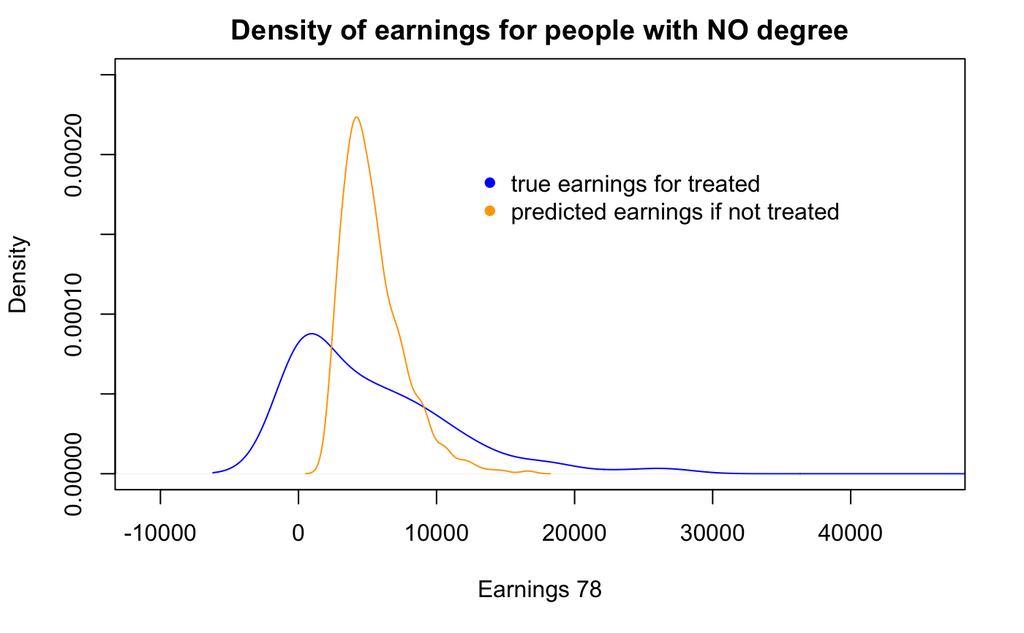

```r
legend(x=40000, y=0.00020, xjust=1, col = c("blue","orange"), legend = c("true earnings for treated", "predicted earnings if not treated"),  bty="n", pch= c(16, 16) )
```

So, the treatment effect for treated people WITH NO DEGREE is: $250.76 This is MUCH lower, almost miniscule, compared to the treatment effect for treated people WITH DEGREE, which was: $2647.82. Meaning, people with degree gained from the treatment, on average, **$2397.06** more than people without degree gained from the treatment. ($2647.82 vs $250.76).

# 3. Implement a Fisher Exact Test (FET) using the sharp null hypothesis of no treatment effect for any unit.

1. Defining a test statistic for estimating the treatment effect and evaluating the null hypothesis: ** We define the test statistic as the mean of earnings for all units minus mean of all units untreated (y(1) ??? y(0)) **

Calculating the actual observed treatment effect between the original groups:

```r
original_observed_meandiff <- (mean(lalonde[treat == 1,]$re78) - mean(lalonde[treat == 0,]$re78))
original_observed_meandiff
```

[output not shown]

The original observed treatment effect between the original groups is: $1794.343.

2. Defining a sharp null hypothesis (hypothesis regarding the size of the treatment effect on each unit): ** We will define the null hypothesis as “treatment effect = 0”" of absolutely no effect of treatment: (Yi(0) = Yi(1) for all units). **

** To implement Fisher’s exact test, we will take random assignments to treatemnet, calcualte the observed average treatement effect for each random assignment, and store these results in a storage list. **

Now we will make many random assignments of the units to control and treatment groups.

For each random assignment: a. Calculate treatment effect: Average all Y(1)s -minus all Y(0) results. (this would depend on the initial values; if I happen to assign to the treatment all units with smaller values, and the larger values to the control, I would get a negative average treatment effect even if for each unit individually is increasing with treatment.)

```
  b. Save this treatment effect to a list of treatment effects (1 for each assignment).
```

Here we create the assignment function, which randomizes into treatment and control groups, and returns the observed average treatment effect for that assignment.

```r
# Assignment function: randomizes groups and returns the observed average treatment effect
rand_assign_mean <- function() {
  #randomizing units to be treated: half of the people
  randtreat <- sample(nrow(lalonde),nrow(randomlalonde)/2,replace = FALSE)

  #taking the rest to be control
  randcontrol <- nrow(lalonde)-randtreat

  #assigning vectors of outcomes
  randcontrol_outcomes <- lalonde[randcontrol,]$re78
  randtreatmnet_outcomes <- lalonde[randtreat,]$re78

  #calculate the observed mean treatment effect
  return(mean(randtreatmnet_outcomes) - mean(randcontrol_outcomes))
}
```

Now we will iterate through many of these random assignments:

```r
### *this code snippet is assited by Ben Imadali's code.
#initiating a storage list vector (empty for now, later will store our results)
storage <- NULL
# Iterating the Assignment function
iter.RI <- function(iterations = 500) {
  for (i in 1:iterations)
  {storage[i] <- rand_assign_mean()
  }
  return(storage)
}
results <- iter.RI()
head(results)
```

```
[1] -208.42273  125.53434 -284.84794   12.38148  -39.02244 1004.30702
```